# event_studies

wmh

2024-04-04

# 13.事件研究

过往章节中，我们已经学习了一下检测金融市场对信息的反应的论文，FFJR研究了股票对与分股的价格反应，Ball 和Brown展示了一年多的回报与盈余新闻相对应。Beaver的研究表明盈余公告前后交易量和价格波动性会增加

这些论文发表后的几十年中，研究人员研究市场对于信息的反应的方式已经发生了重大变革。本章提供了对于现在时间研究方法的介绍

```r
library(dplyr, warn.conflicts = FALSE)
library(DBI)
library(dbplyr)       # For window_order()
```

```r
library(ggplot2)
library(farr)
library(modelsummary)
```

## 13.1 Overview

MacKinlay(1997)将事件研究法定义为:使用金融市场的数据……衡量滴定时间对于公司价值的影响。这样一种研究的有效应来源于：鉴于市场的理性，时间的影响会立即反映到证券价格中,因此可以使用在相关短时间内观测到的证券价格，来衡量事件的经济影响

实践研究考察一类可识别时间对于一个或多个经济收益变量的影响。在资本市场的研究中，经济收益的变量通常是事件发生前后股票收益的回报

事件研究的基本要素包括： 1. 事件类别：包括盈利公告、并购公告、股票分拆、盈利预测变更等。 2. 研究关注的变量：如会计政策、市场回报率、交易量等。 3. 对照观察：指事件未发生时的观察。 4. 控制变量：可能与事件相关的额外变量，例如与盈利公告相关的股利公告或盈利预测修正，以及回报率

## 13.2现在的事件研究

事件研究随着时间的推移而发展。虽然今天的事件研究通常符合MacKinlay（1997）的定义，但随着其被适应到更广泛的情境中，事件研究方法也发生了变化。

1. 研究人员更加倾向于使用事件研究来理解法规的经济效应，而不是市场对公司特定公告的反应。Fama等人（1969年）研究了股票分拆，Beaver（1968年）研究了盈利公告。在每种情况下，这些事件都是公司层面的事件，彼此之间基本独立（例如，它们在时间上并不过分集中）。相比之下，我们将在下文中研究的三个较新的事件研究中，每一个都使用了影响立法可能性的事件（Larcker等，2011年；Zhang，2007年）或会计准则生效的事件（Khan等，2017年）等法规事件
2. 是对市场效率的更大依赖，因为典型的现代事件研究使用（借用MacKinlay，1997年的话）“在相对较短的时间段内观察到的证券价格”作为“事件经济影响的度量”。Fama等人（1969年）和Beaver（1968年）在建立市场对股票分拆和盈利公告的反应时都没有过多依赖市场效率，并且两项研究都没有试图证明股票分拆或盈利公告是否创造（或破坏）价值。相比之下，现代事件研究通常依赖市场效率来评估法规。例如，使用事件研究来询问“FASB的准则是否增加股东价值？”（Khan等，2017年）在很大程度上依赖市场具有一种由更强形式的市场效率所暗示的知情观点

这种重点转变的一个后果是研究人员通常有更少的独立观察数据可供使用。例如，Zhang（2007年）的主要分析集中在四个事件窗口上，远远少于Beaver（1968年）的506个盈利公告。正如我们将看到的，研究人员通常使用补充分析来解决数据相对匮乏的问题。

### 13.2.1 一个小的事件研究

为了更好地理解现代事件研究，我们将进行一项小型研究。假设我们希望更好地了解苹果公司的价值创造过程，特别关注苹果的产品开发过程。在撰写本文时（2022年中），苹果是世界上市值最高的公司，市值超过2万亿美元，因此了解其如何为股东创造价值对研究人员具有吸引力。

由于苹果对其产品管道保密性极高，其产品发布的媒体事件备受关注。例如，在2007年1月9日的Macworld Conference & Expo San Francisco上，苹果宣布了iPhone，后来成为苹果的主要收入来源和世界上最大的手机产品之一。在2010年1月27日的苹果特别活动上，苹果宣布了iPad，苹果的平板电脑。

因此，为了了解苹果的产品是否为苹果股东创造价值，我们可以利用苹果的媒体事件作为感兴趣的事件进行事件研究

```r
tail(apple_events)
```

```
## # A tibble: 6 x 3
##   event               event_date end_event_date
##   <chr>               <date>     <date>
## 1 Apple Special Event 2019-09-10 2019-09-10
## 2 Apple Special Event 2019-12-02 2019-12-02
## 3 WWDC 2020           2020-06-22 2020-06-26
## 4 Apple Special Event 2020-09-15 2020-09-15
## 5 Apple Special Event 2020-10-13 2020-10-13
## 6 Apple Special Event 2020-11-10 2020-11-10
```

```r
write.csv(apple_events, file = "G:/wangmenghan/Dropbox/Study_2024Spring/data/04_event_study/apple_events.csv", row.names = FALSE)
```

我们需要从CRSP获取返回数据来进行我们的事件研究。我们首先需要获取苹果的PERMNO，这样我们就可以在CRSP上查找返回数据。知道苹果的股票代码是AAPL有所帮助。

```r
Sys.setenv(PGHOST = "wrds-pgdata.wharton.upenn.edu",
           PGPORT = 9737L,
           PGUSER = "sam0302",
           PGDATABASE = "wrds")
```

```r
db <- dbConnect(RPostgres::Postgres(),
                host = "wrds-pgdata.wharton.upenn.edu",
                port = 9737L,
                user = "sam0302",
                password = "Friedfish825#6",
                dbname ="wrds",
                bigint = "integer")
```

```r
stocknames <- tbl(db, Id(schema = "crsp", table = "stocknames"))

## 日度的股票价格和成交量信息
dsf <- tbl(db, Id(schema = "crsp", table = "dsf"))
## 股票的股利支付和分红信息
dsi <- tbl(db, Id(schema = "crsp", table = "dsi"))
## 2005年

## 每日指数的信息
idx_daily <- tbl(db, Id(schema = "comp", table = "idx_daily"))
```

```r
apple_permno <-
  stocknames |>
  filter(ticker == "AAPL") |>
  select(permno) |>
  distinct() |>
  pull()

apple_permno
```

```
## [1] 14593
```

然后我们使用苹果的PERMNO（14593）从CRSP获取返回数据。在这种情况下，我们将从crsp.dsf获取苹果的日收益率（ret），从crsp.dsi获取加权“市场”收益率（vwretd），并计算市场调整后的收益率为ret - vwretd。在这种情况下，我们将获取自2005年初以来的所有收益率数据，这涵盖了apple_events上的所有事件。

```r
apple_rets <-
  dsf |>
  inner_join(dsi, by = "date") |>
  mutate(ret_mkt = ret - vwretd) |>
  select(permno, date, ret, ret_mkt, vol) |>
  filter(permno == apple_permno,
         date >= "2005-01-01") |>
  collect()
```

```r
apple_rets
```

```
## # A tibble: 4,781 x 5
##    permno date             ret   ret_mkt      vol
##     <int> <date>         <dbl>     <dbl>    <dbl>
##  1  14593 2005-01-03 -0.0172   -0.00720  12442426
##  2  14593 2005-01-04  0.0103    0.0231   19650028
##  3  14593 2005-01-05  0.00876   0.0149   12196008
##  4  14593 2005-01-06  0.000775 -0.00271  12610986
##  5  14593 2005-01-07  0.0728    0.0750   39944563
##  6  14593 2005-01-10 -0.00419  -0.0084   31079383
##  7  14593 2005-01-11 -0.0638   -0.0575   46753220
##  8  14593 2005-01-12  0.0139    0.00973  36727541
##  9  14593 2005-01-13  0.0663    0.0732   56719585
## 10  14593 2005-01-14  0.00573  -0.000509 27466847
## # i 4,771 more rows
```

与我们在第12章中研究的盈利公告不同，苹果的媒体事件延续多天，因此我们的事件窗口也需要延伸多天。为了允许信息在媒体事件开始前一天泄漏，并让市场有些时间来处理媒体事件的价值影响，我们将设置我们的事件窗口从每个媒体事件开始前一天的交易日开始，延续至媒体事件结束后的第二天。我们将使用farr包中的get_event_dates()函数来实现这一点；在幕后，该函数使用get_trading_dates()和get_annc_dates()函数来获取类似我们在第12章中研究的交易日期和公告日期等表格。

```r
apple_event_dates <-
  apple_events |>
  mutate(permno = apple_permno) |>
  get_event_dates(db,
                  end_event_date = "end_event_date",
                  win_start = -1, win_end = +1)

tail(apple_event_dates)
```

```
## # A tibble: 6 x 5
##   permno event_date end_event_date start_date end_date
##    <int> <date>     <date>         <date>     <date>
## 1  14593 2019-09-10 2019-09-10     2019-09-09 2019-09-11
## 2  14593 2019-12-02 2019-12-02     2019-11-29 2019-12-03
## 3  14593 2020-06-22 2020-06-26     2020-06-19 2020-06-29
## 4  14593 2020-09-15 2020-09-15     2020-09-14 2020-09-16
## 5  14593 2020-10-13 2020-10-13     2020-10-12 2020-10-14
## 6  14593 2020-11-10 2020-11-10     2020-11-09 2020-11-11
```

现在，我们组织数据的方式可以使我们在图形上以时间为单位描绘苹果的收益，其中包括媒体事件的信息。

```r
apple_reg_data <-
  apple_rets |>
  left_join(apple_event_dates,
            join_by(permno, date >= start_date, date <= end_date)) |>
  mutate(is_event = !is.na(start_date)) |>
  select(permno, date, ret, ret_mkt, vol, is_event)
```

```r
apple_rets |>
  left_join(apple_event_dates,
            join_by(permno, date >= start_date, date <= end_date)) |>
  mutate(is_event = !is.na(start_date))
```

```
## # A tibble: 4,781 x 10
##    permno date             ret   ret_mkt      vol event_date end_event_date
##     <int> <date>         <dbl>     <dbl>    <dbl> <date>     <date>
##  1  14593 2005-01-03 -0.0172   -0.00720  12442426 NA         NA
##  2  14593 2005-01-04  0.0103    0.0231   19650028 NA         NA
##  3  14593 2005-01-05  0.00876   0.0149   12196008 NA         NA
##  4  14593 2005-01-06  0.000775 -0.00271  12610986 NA         NA
##  5  14593 2005-01-07  0.0728    0.0750   39944563 NA         NA
##  6  14593 2005-01-10 -0.00419  -0.0084   31079383 NA         NA
##  7  14593 2005-01-11 -0.0638   -0.0575   46753220 NA         NA
##  8  14593 2005-01-12  0.0139    0.00973  36727541 NA         NA
##  9  14593 2005-01-13  0.0663    0.0732   56719585 NA         NA
## 10  14593 2005-01-14  0.00573  -0.000509 27466847 NA         NA
## # i 4,771 more rows
## # i 3 more variables: start_date <date>, end_date <date>, is_event <lgl>
```

```r
apple_reg_data
```

```
## # A tibble: 4,781 x 6
##    permno date             ret   ret_mkt      vol is_event
##     <int> <date>         <dbl>     <dbl>    <dbl> <lgl>
##  1  14593 2005-01-03 -0.0172   -0.00720  12442426 FALSE
##  2  14593 2005-01-04  0.0103    0.0231   19650028 FALSE
##  3  14593 2005-01-05  0.00876   0.0149   12196008 FALSE
##  4  14593 2005-01-06  0.000775 -0.00271  12610986 FALSE
##  5  14593 2005-01-07  0.0728    0.0750   39944563 FALSE
##  6  14593 2005-01-10 -0.00419  -0.0084   31079383 FALSE
##  7  14593 2005-01-11 -0.0638   -0.0575   46753220 FALSE
##  8  14593 2005-01-12  0.0139    0.00973  36727541 FALSE
##  9  14593 2005-01-13  0.0663    0.0732   56719585 FALSE
## 10  14593 2005-01-14  0.00573  -0.000509 27466847 FALSE
## # i 4,771 more rows
```

现在我们拥有了所需的数据，我们可以使用cumprod()函数计算累积收益，然后将这些收益随时间绘制出来。

```r
apple_reg_data |>
  arrange(date) |>
  mutate(cumret = cumprod(1 + coalesce(ret, 0)),
         switch = coalesce(is_event != lead(is_event), FALSE))
```

```
## # A tibble: 4,781 x 8
##    permno date             ret   ret_mkt      vol is_event cumret switch
##     <int> <date>         <dbl>     <dbl>    <dbl> <lgl>     <dbl> <lgl>
##  1  14593 2005-01-03 -0.0172   -0.00720  12442426 FALSE     0.983 FALSE
##  2  14593 2005-01-04  0.0103    0.0231   19650028 FALSE     0.993 FALSE
##  3  14593 2005-01-05  0.00876   0.0149   12196008 FALSE     1.00  FALSE
##  4  14593 2005-01-06  0.000775 -0.00271  12610986 FALSE     1.00  FALSE
##  5  14593 2005-01-07  0.0728    0.0750   39944563 FALSE     1.08  FALSE
##  6  14593 2005-01-10 -0.00419  -0.0084   31079383 FALSE     1.07  FALSE
##  7  14593 2005-01-11 -0.0638   -0.0575   46753220 FALSE     1.00  FALSE
##  8  14593 2005-01-12  0.0139    0.00973  36727541 FALSE     1.02  FALSE
##  9  14593 2005-01-13  0.0663    0.0732   56719585 FALSE     1.08  FALSE
## 10  14593 2005-01-14  0.00573  -0.000509 27466847 FALSE     1.09  FALSE
## # i 4,771 more rows
```

```r
apple_reg_data |>
  arrange(date) |>
  mutate(cumret = cumprod(1 + coalesce(ret, 0)),
         switch = coalesce(is_event != lead(is_event), FALSE)) |>
  ggplot(aes(x = date, y = cumret)) +
  geom_line() +
  geom_ribbon(aes(ymax = if_else(!is_event | switch, cumret, NA),
                  ymin = 0,
                  fill = "Non-event")) +
  geom_ribbon(aes(ymax = if_else(is_event | switch, cumret, NA),
                  ymin = 0,
                  fill = "Event")) +
  theme(legend.position = "bottom")
```

[output not shown]

```r
apple_reg_data |>
  arrange(date) |>
  mutate(cumret = cumprod(1 + coalesce(ret, 0)),
         switch = coalesce(is_event != lead(is_event), FALSE)) |>
  filter(date >= "2020-09-01", date <= "2020-12-31") |>
  ggplot(aes(x = date, y = cumret)) +
  geom_line() +
  geom_ribbon(aes(ymax = if_else(!is_event | switch, cumret, NA),
                  ymin = 0, fill = "Non-event")) +
  geom_ribbon(aes(ymax = if_else(is_event | switch, cumret, NA),
                  ymin = 0, fill = "Event")) +
  theme(legend.position = "bottom")
```

[output not shown]

上述图表中很少有迹象表明苹果媒体事件与异常收益有关，但我们将使用回归分析来更正式地测试这一点。我们考虑当指示变量is_event为TRUE时收益是否不同。受Beaver (1968)（第12章）的启发，我们还考虑了收益的绝对值（类似于Beaver (1968)中使用的平方收益残差）和相对交易量。

```r
fms <- list("ret_mkt" = lm(ret_mkt ~ is_event, data = apple_reg_data),
            "abs(ret)" = lm(abs(ret) ~ is_event, data = apple_reg_data),
            "Volume" = lm(vol/mean(vol) ~ is_event, data = apple_reg_data))
```

```r
modelsummary(fms,
             estimate = "{estimate}",
             statistic = NULL,
             gof_map = c("nobs", "r.squared"),
             stars = c('*' = .1, '**' = 0.05, '***' = .01))
```

|  | ret_mkt | abs(ret) | Volume |
| --- | --- | --- | --- |
| (Intercept) | 0.001 | 0.014 | 0.997 |
| is_eventTRUE | -0.002 | 0.001 | 0.060 |
| Num.Obs. | 4781 | 4781 | 4781 |
| R2 | 0.001 | 0.000 | 0.000 |

* p < 0.1, ** p < 0.05, *** p < 0.01

这些回归分析（比较随意地解释）提供了更高的交易量的证据，但没有更高（或更低）的收益或更高的收益波动性。

上述代码检查了苹果在事件期间的收益是否与非事件期间的收益行为有所不同。farr中的另一个函数get_event_cum_rets，使用两种方法计算了累积原始收益和累积异常收益：市场调整收益和规模调整收益。在这里，我们使用此函数来获取每个苹果事件周围窗口的累积收益。

```r
rets <-
  apple_events |>
  mutate(permno = apple_permno) |>
  get_event_cum_rets(db,
                     win_start = -1, win_end = +1,
                     end_event_date = "end_event_date")
```

```r
rets
```

```
## # A tibble: 47 x 6
##    permno event_date end_event_date ret_raw  ret_mkt   ret_sz
##     <int> <date>     <date>           <dbl>    <dbl>    <dbl>
##  1  14593 2012-10-23 2012-10-23      0.0115  0.0268   0.0281
##  2  14593 2019-06-03 2019-06-07      0.0801  0.0468   0.0457
##  3  14593 2011-06-06 2011-06-10     -0.0563 -0.0217  -0.0247
##  4  14593 2018-06-04 2018-06-08      0.0233 -0.00396 -0.00478
##  5  14593 2006-02-28 2006-02-28     -0.0330 -0.0359  -0.0354
##  6  14593 2014-06-02 2014-06-06      0.0323  0.0144   0.0164
##  7  14593 2012-03-07 2012-03-07      0.0166  0.0154   0.0158
##  8  14593 2016-09-07 2016-09-07     -0.0205 -0.0226  -0.0214
##  9  14593 2013-09-10 2013-09-10     -0.0612 -0.0822  -0.0819
## 10  14593 2017-06-05 2017-06-09     -0.0507 -0.0511  -0.0499
## # i 37 more rows
```

```r
summary(rets$ret_mkt)
```

```
##      Min.   1st Qu.    Median      Mean   3rd Qu.      Max.
## -0.103893 -0.026442 -0.007216 -0.005840  0.014284  0.135833
```

```r
summary(rets$ret_mkt > 0)
```

```
##    Mode   FALSE    TRUE
## logical      26      21
```

最后，我们按事件日期制作了苹果媒体事件的市场调整收益的散点图（图13.3）。

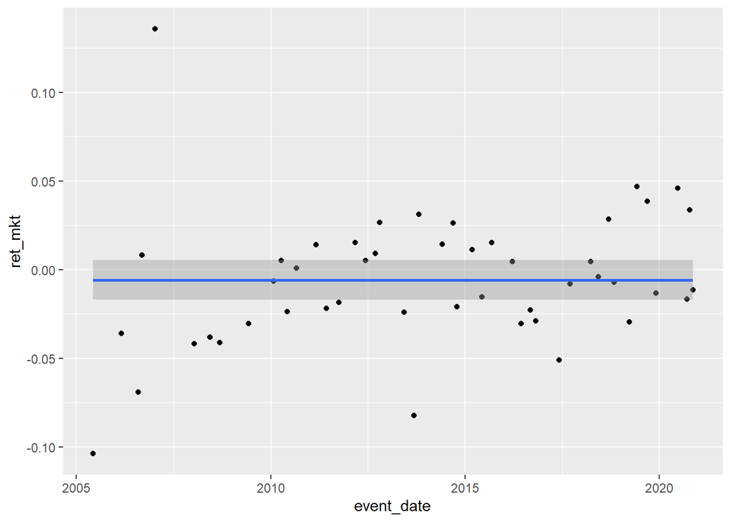

```r
rets |>
  ggplot(aes(x = event_date, y = ret_mkt)) +
  geom_point() +
  geom_smooth(method = "lm", formula = "y ~ 1")
```

### 13.2.2 练习

#### 13.2.2.1

```r
apple_reg_data |>
  arrange(date) |>
  mutate(cumret = exp(cumsum(log(1 + coalesce(ret,0)))),
         switch = coalesce(is_event != lead(is_event), FALSE))
```

```
## # A tibble: 4,781 x 8
##    permno date             ret   ret_mkt      vol is_event cumret switch
##     <int> <date>         <dbl>     <dbl>    <dbl> <lgl>     <dbl> <lgl>
##  1  14593 2005-01-03 -0.0172   -0.00720  12442426 FALSE     0.983 FALSE
##  2  14593 2005-01-04  0.0103    0.0231   19650028 FALSE     0.993 FALSE
##  3  14593 2005-01-05  0.00876   0.0149   12196008 FALSE     1.00  FALSE
##  4  14593 2005-01-06  0.000775 -0.00271  12610986 FALSE     1.00  FALSE
##  5  14593 2005-01-07  0.0728    0.0750   39944563 FALSE     1.08  FALSE
##  6  14593 2005-01-10 -0.00419  -0.0084   31079383 FALSE     1.07  FALSE
##  7  14593 2005-01-11 -0.0638   -0.0575   46753220 FALSE     1.00  FALSE
##  8  14593 2005-01-12  0.0139    0.00973  36727541 FALSE     1.02  FALSE
##  9  14593 2005-01-13  0.0663    0.0732   56719585 FALSE     1.08  FALSE
## 10  14593 2005-01-14  0.00573  -0.000509 27466847 FALSE     1.09  FALSE
## # i 4,771 more rows
```

```r
apple_reg_data |>
  arrange(date) |>
  mutate(cumret = exp(cumsum(log(1 + coalesce(ret,0)))),
         switch = coalesce(is_event != lead(is_event), FALSE)) |>
  ggplot(aes(x = date, y = cumret)) +
  geom_line() +
  geom_ribbon(aes(ymax = if_else(!is_event | switch, cumret, NA),
                  ymin = 0,
                  fill = "Non-event")) +
  geom_ribbon(aes(ymax = if_else(is_event | switch, cumret, NA),
                  ymin = 0,
                  fill = "Event")) +
  theme(legend.position = "bottom")
```

[output not shown]

```r
apple_reg_data |>
  arrange(date) |>
  mutate(cumret = exp(cumsum(log(1 + coalesce(ret,0)))),
         switch = coalesce(is_event != lead(is_event), FALSE)) |>
  filter(date >= "2020-09-01", date <= "2020-12-31") |>
  ggplot(aes(x = date, y = cumret)) +
  geom_line() +
  geom_ribbon(aes(ymax = if_else(!is_event | switch, cumret, NA),
                  ymin = 0, fill = "Non-event")) +
  geom_ribbon(aes(ymax = if_else(is_event | switch, cumret, NA),
                  ymin = 0, fill = "Event")) +
  theme(legend.position = "bottom")
```

[output not shown]

#### 13.2.2.2

```r
apple_reg_data |>
  arrange(date) |>
  mutate(cumret = cumprod(1 + ret),
         switch = coalesce(is_event != lead(is_event), FALSE))
```

```
## # A tibble: 4,781 x 8
##    permno date             ret   ret_mkt      vol is_event cumret switch
##     <int> <date>         <dbl>     <dbl>    <dbl> <lgl>     <dbl> <lgl>
##  1  14593 2005-01-03 -0.0172   -0.00720  12442426 FALSE     0.983 FALSE
##  2  14593 2005-01-04  0.0103    0.0231   19650028 FALSE     0.993 FALSE
##  3  14593 2005-01-05  0.00876   0.0149   12196008 FALSE     1.00  FALSE
##  4  14593 2005-01-06  0.000775 -0.00271  12610986 FALSE     1.00  FALSE
##  5  14593 2005-01-07  0.0728    0.0750   39944563 FALSE     1.08  FALSE
##  6  14593 2005-01-10 -0.00419  -0.0084   31079383 FALSE     1.07  FALSE
##  7  14593 2005-01-11 -0.0638   -0.0575   46753220 FALSE     1.00  FALSE
##  8  14593 2005-01-12  0.0139    0.00973  36727541 FALSE     1.02  FALSE
##  9  14593 2005-01-13  0.0663    0.0732   56719585 FALSE     1.08  FALSE
## 10  14593 2005-01-14  0.00573  -0.000509 27466847 FALSE     1.09  FALSE
## # i 4,771 more rows
```

```r
apple_reg_data |>
  arrange(date) |>
  mutate(cumret = cumprod(1 + ret),
         switch = coalesce(is_event != lead(is_event), FALSE)) |>
  ggplot(aes(x = date, y = cumret)) +
  geom_line() +
  geom_ribbon(aes(ymax = if_else(!is_event | switch, cumret, NA),
                  ymin = 0,
                  fill = "Non-event")) +
  geom_ribbon(aes(ymax = if_else(is_event | switch, cumret, NA),
                  ymin = 0,
                  fill = "Event")) +
  theme(legend.position = "bottom")
```

[output not shown]

```r
apple_reg_data |>
  arrange(date) |>
  mutate(cumret = cumprod(1 + ret),
         switch = coalesce(is_event != lead(is_event), FALSE)) |>
  filter(date >= "2020-09-01", date <= "2020-12-31") |>
  ggplot(aes(x = date, y = cumret)) +
  geom_line() +
  geom_ribbon(aes(ymax = if_else(!is_event | switch, cumret, NA),
                  ymin = 0, fill = "Non-event")) +
  geom_ribbon(aes(ymax = if_else(is_event | switch, cumret, NA),
                  ymin = 0, fill = "Event")) +
  theme(legend.position = "bottom")
```

[output not shown]

## 13.3 事件研究与法规

Zhang（2007年，第74页）通过审查与相关立法事件相关的市场反应，“调查了萨班斯-奥克斯法案（SOX）的经济后果。” Zhang（2007年，第75页）发现“美国市场加权（等权）原始收益的累积值分别为-15.35%（-12.53%）左右，围绕着关键的SOX事件。”由于Zhang（2007年）使用CRSP返回美国市场数据，因此我们收集了相关数据的本地副本。

```r
dsi_local <-
  dsi |>
  select(date, vwretd, ewretd) |>
  collect()
```

```r
can_rets <-
  idx_daily |>
  filter(gvkeyx == "000193") |>
  window_order(datadate) |>
  mutate(ret_can = if_else(lag(prccd) > 0, prccd/lag(prccd) - 1, NA)) |>
  filter(datadate >= "2000-01-01", datadate <= "2002-12-31") |>
  rename(date = datadate) |>
  select(date, ret_can) |>
  collect()
```

```r
can_rets
```

```
## # A tibble: 742 x 2
##    date        ret_can
##    <date>        <dbl>
##  1 2000-01-04 -0.0251
##  2 2000-01-06 -0.0108
##  3 2000-01-07  0.0388
##  4 2000-01-10  0.0205
##  5 2000-01-11 -0.0186
##  6 2000-01-12 -0.00974
##  7 2000-01-13  0.00694
##  8 2000-01-17  0.00729
##  9 2000-01-18  0.0130
## 10 2000-01-19  0.00529
## # i 732 more rows
```

```r
reg_data <-
  dsi_local |>
  inner_join(can_rets, by = "date") |>
  filter(date < "2001-12-28") |>
  top_n(100, wt = date)
```

```r
reg_data
```

```
## # A tibble: 100 x 4
##    date         vwretd    ewretd  ret_can
##    <date>        <dbl>     <dbl>    <dbl>
##  1 2001-07-25  0.0137   0.00276   0.00492
##  2 2001-07-26  0.0115   0.00767  -0.00276
##  3 2001-07-27  0.00330  0.00352   0.0105
##  4 2001-07-30 -0.00118 -0.00114  -0.00526
##  5 2001-07-31  0.00489  0.00322   0.00633
##  6 2001-08-01  0.00504  0.00645   0.00692
##  7 2001-08-02  0.00322  0.00253   0.00191
##  8 2001-08-03 -0.00463  0.000534 -0.00150
##  9 2001-08-07  0.00225 -0.000388  0.00362
## 10 2001-08-08 -0.0167  -0.0100   -0.0151
## # i 90 more rows
```

```r
fm_vw <- lm(vwretd ~ ret_can, data = reg_data)
fm_ew <- lm(ewretd ~ ret_can, data = reg_data)
```

```r
summary(fm_vw)
```

```
##
## Call:
## lm(formula = vwretd ~ ret_can, data = reg_data)
##
## Residuals:
##       Min        1Q    Median        3Q       Max
## -0.052684 -0.003628 -0.000423  0.004535  0.016023
##
## Coefficients:
##               Estimate Std. Error t value Pr(>|t|)
## (Intercept) -0.0006544  0.0008420  -0.777    0.439
## ret_can      1.0427970  0.0899447  11.594   <2e-16 ***
## ---
## Signif. codes:  0 '***' 0.001 '**' 0.01 '*' 0.05 '.' 0.1 ' ' 1
##
## Residual standard error: 0.008383 on 98 degrees of freedom
## Multiple R-squared:  0.5783, Adjusted R-squared:  0.574
## F-statistic: 134.4 on 1 and 98 DF,  p-value: < 2.2e-16
```

```r
summary(fm_ew)
```

```
##
## Call:
## lm(formula = ewretd ~ ret_can, data = reg_data)
##
## Residuals:
##       Min        1Q    Median        3Q       Max
## -0.044736 -0.003078  0.000551  0.003530  0.013628
##
## Coefficients:
##              Estimate Std. Error t value Pr(>|t|)
## (Intercept) 0.0002280  0.0007131    0.32     0.75
## ret_can     0.8457027  0.0761783   11.10   <2e-16 ***
## ---
## Signif. codes:  0 '***' 0.001 '**' 0.01 '*' 0.05 '.' 0.1 ' ' 1
##
## Residual standard error: 0.0071 on 98 degrees of freedom
## Multiple R-squared:  0.5571, Adjusted R-squared:  0.5525
## F-statistic: 123.2 on 1 and 98 DF,  p-value: < 2.2e-16
```

```r
dsi_merged <-
  dsi_local |>
  inner_join(can_rets, by = "date") |>
  mutate(abret_vw = vwretd - predict(fm_vw, newdata = pick(everything())),
         abret_ew = ewretd - predict(fm_ew, newdata = pick(everything()))) |>
  select(-ret_can)
```

```r
dsi_merged
```

```
## # A tibble: 726 x 5
##    date         vwretd   ewretd  abret_vw  abret_ew
##    <date>        <dbl>    <dbl>     <dbl>     <dbl>
##  1 2000-01-04 -0.0397  -0.0175  -0.0128    0.00353
##  2 2000-01-06 -0.00739  0.00450  0.00448   0.0134
##  3 2000-01-07  0.0325   0.0170  -0.00733  -0.0161
##  4 2000-01-10  0.0186   0.0153  -0.00215  -0.00226
##  5 2000-01-11 -0.0169  -0.00608  0.00310   0.00941
##  6 2000-01-12 -0.00692 -0.00250  0.00389   0.00550
##  7 2000-01-13  0.0163   0.0131   0.00969   0.00697
##  8 2000-01-18 -0.00086  0.0120  -0.0138    0.000803
##  9 2000-01-19  0.00463  0.00812 -0.000230  0.00342
## 10 2000-01-20 -0.00280  0.00347 -0.00793  -0.00145
## # i 716 more rows
```

```r
sd_ret <-
  dsi_local |>
  filter(date < "2001-12-28") |>
  top_n(100, wt = date) |>
  summarize(sd(vwretd)) |>
  pull()
```

```r
sd_ret
```

```
## [1] 0.01280036
```

```r
zhang_2007_windows
```

```
## # A tibble: 17 x 3
##    event beg_date   end_date
##    <int> <date>     <date>
##  1     1 2002-01-15 2002-01-18
##  2     2 2002-02-01 2002-02-04
##  3     3 2002-02-11 2002-02-14
##  4     4 2002-02-27 2002-03-01
##  5     5 2002-03-06 2002-03-08
##  6     6 2002-03-25 2002-03-27
##  7     7 2002-04-11 2002-04-12
##  8     8 2002-04-16 2002-04-17
##  9     9 2002-04-24 2002-04-26
## 10    10 2002-05-07 2002-05-09
## 11    11 2002-06-10 2002-06-13
## 12    12 2002-06-18 2002-06-19
## 13    13 2002-06-25 2002-06-27
## 14    14 2002-07-08 2002-07-12
## 15    15 2002-07-15 2002-07-17
## 16    16 2002-07-18 2002-07-23
## 17    17 2002-07-24 2002-07-26
```

```r
write.csv(zhang_2007_windows,file = "G:/wangmenghan/Dropbox/Study_2024Spring/data/04_event_study/zhang_2007_windows.csv", row.names = FALSE)
```

```r
zhang_2007_rets <-
  zhang_2007_windows |>
  inner_join(dsi_merged, join_by(beg_date <= date, end_date >= date)) |>
  group_by(event) |>
  summarize(n_days = n(),
            vwret = sum(vwretd),
            ewret = sum(ewretd),
            abret_vw = sum(abret_vw),
            abret_ew = sum(abret_ew),
            vw_t_stat = vwret / (sqrt(n_days) * sd_ret),
            ew_t_stat = ewret / (sqrt(n_days) * sd_ret),
            abret_vw_t_stat = abret_vw / (sqrt(n_days) * sd(fm_vw$residuals)),
            abret_ew_t_stat = abret_ew / (sqrt(n_days) * sd(fm_ew$residuals)))
```

```r
zhang_2007_rets
```

```
## # A tibble: 17 x 10
##    event n_days    vwret    ewret  abret_vw  abret_ew vw_t_stat ew_t_stat
##    <int>  <int>    <dbl>    <dbl>     <dbl>     <dbl>     <dbl>     <dbl>
##  1     1      4 -0.0105  -0.00916 -0.00257  -0.00574     -0.411   -0.358
##  2     2      2 -0.0303  -0.0183  -0.0212   -0.0125      -1.67    -1.01
##  3     3      4  0.0171   0.00871  0.0206    0.00849      0.667    0.340
##  4     4      3  0.0200   0.0139   0.00202  -0.00302      0.904    0.625
##  5     5      3  0.0171   0.0251   0.0116    0.0183       0.771    1.13
##  6     6      3 -0.00306  0.00336  0.000889  0.00428     -0.138    0.151
##  7     7      2 -0.0131   0.00131 -0.00264   0.00826     -0.723    0.0721
##  8     8      2  0.0200   0.0175   0.00696   0.00537      1.10     0.964
##  9     9      3 -0.0213  -0.0137  -0.00745  -0.00469     -0.962   -0.617
## 10    10      3  0.0168   0.00547  0.0114   -0.00122      0.759    0.247
## 11    11      4 -0.0199  -0.0230   0.00945  -0.00225     -0.778   -0.899
## 12    12      2 -0.0152  -0.0149   0.00138  -0.00299     -0.838   -0.822
## 13    13      3 -0.00238 -0.00467  0.00673   0.000443    -0.107   -0.211
## 14    14      5 -0.0637  -0.0366  -0.0169   -0.00239     -2.23    -1.28
## 15    15      3 -0.0131  -0.00539  0.00707   0.00870     -0.591   -0.243
## 16    16      4 -0.120   -0.0852  -0.0314   -0.0166      -4.67    -3.33
## 17    17      3  0.0615   0.0219   0.0377    0.000375     2.77     0.989
## # i 2 more variables: abret_vw_t_stat <dbl>, abret_ew_t_stat <dbl>
```

```r
zhang_2007_res <-
  zhang_2007_rets |>
  filter(abs(vw_t_stat) > abs(qnorm(.05))) |>
  summarize(vwret = sum(vwret),
            ewret = sum(ewret),
            abret_vw = sum(abret_vw),
            abret_ew = sum(abret_ew),
            n_days = sum(n_days),
            vw_t_stat = vwret / (sqrt(n_days) * sd_ret),
            ew_t_stat = ewret / (sqrt(n_days) * sd_ret),
            abret_vw_t_stat = abret_vw / (sqrt(n_days) * sd(fm_vw$residuals)),
            abret_ew_t_stat = abret_ew / (sqrt(n_days) * sd(fm_ew$residuals)))
```

```r
zhang_2007_res
```

```
## # A tibble: 1 x 9
##    vwret  ewret abret_vw abret_ew n_days vw_t_stat ew_t_stat abret_vw_t_stat
##    <dbl>  <dbl>    <dbl>    <dbl>  <int>     <dbl>     <dbl>           <dbl>
## 1 -0.152 -0.118  -0.0318  -0.0311     14     -3.18     -2.47           -1.02
## # i 1 more variable: abret_ew_t_stat <dbl>
```

```r
dbDisconnect(db)
```